# Administrative Democracy

Author

Devin Judge-Lord

Published

October 9, 2026

What institutional mechanisms advance administrative democracy? To be effective, must they be identity-conscious and ends-oriented? Carpenter (2023) points to the “democratic necessity of local political intermediaries, protest campaigns, social organizations, advocacy campaigns, grievance mechanisms, and other agenda-democratizing processes and institutions.” Policies don’t merely create mass politics; they also structure the inevitable and ongoing politics of “filling up the details” and adapting to change (Moynihan and Soss 2014). Neutral processes likely reproduce existing inequalities. Institutions that resist power are often brought about by social movements and are difficult to maintain when the movement ebbs (Wilson 1989). With most policy still inevitably crafted by bureaucrats, understanding how institutional design makes bureaucratic policymaking responsive to different interests is key, both to understanding the effects of current disruptions and future rebuilding. Redistributive policies will fail if the institutions that “implement” and revise them are responsive to a chorus with an upper-class accent.

## Intermediary institutions as mechanisms of administrative democracy

Agency policymaking tilts toward business (Yackee and Yackee 2006), whose resources give them access to lawyers, experts, and powerful allies (Libgober and Carpenter 2024; Carpenter et al. 2024; Powell et al. 2023). While centralizing control may shift the venue of conflict from agencies to the White House in some areas, the federal government is vast, and the White House bureaucracy has limited capacity. Where the White House is paying little attention, inequality in the ability to articulate claims and demands in ways that bureaucratic policymakers see as legitimate remains a key problem, and lawyers, experts, and allies will likely continue to matter. As one agency official put it, “some groups don’t speak the King’s English”—intermediary institutions must translate.

**On the inside**, public advocates and offices of civil rights, environmental justice, and public participation translate internally, increasing responsiveness to these concerns, but they are marginalized within their institutions (Walton 1988; Harrison 2019). The second Trump administration has rapidly moved to dismantle many, but not all, of these offices, likely with long-term effects. The Federal Energy Regulatory Commission’s Office of Public Participation (OPP) persists. While plans to fund public and consumer advocates are on hold, the OPP continues outreach to affected communities and to help lower-resource groups navigate technical proceedings with major consequences for energy markets and infrastructure. Proactive outreach is impactful in theory but is rarely done (Hertel-Fernandez 2025), and research is thin.

**From the outside**, high-capacity advocacy organizations partner with and thus give voice to low-capacity groups by translating demands into the King’s English. But these partnerships are unequal (Strolovitch 2006; Dwidar 2022). To the extent the White House is able to consolidate authority, the currency of influence may shift from legal and technical legitimacy to access and loyalty, which advocacy groups can only provide under aligned presidents. In contrast, businesses can buy access and pivot loyalties. Protests and petitions can force issues into public discourse and alter the political context of agency decision-making, but they are often dismissed by policymakers who see themselves as expert administrators.

**From below**, state and local governments are active participants in administrative policymaking, often joining coalitions (related to Lisa’s memo).

**Horizontally**, congressional offices oversee executive-branch agencies and act as ombudsmen. A large share of congressional staff work on overseeing executive-branch policymaking and implementation as they route constituent problems to the correct agency, translate, and advocate for resolution. Using data from Judge-Lord et al. (2026), Figure 1 shows that congressional offices’ policy work (e.g., oversight investigations, commenting on rules) focuses on first-face agencies, while constituent casework is disproportionately with second-face agencies, dominated by helping constituents navigate immigration bureaucracies.[^1] But congressional offices are capacity constrained, and the design of the congressional bureaucracy is extremely ad hoc, leading some offices to do much more work to oversee and help their constituents deal with federal agencies than others. Moreover, the congressional bureaucracy is exceptionally White (Jones 2024), and some constituencies, like seniors, are better served than others, like SNAP recipients (Snyder et al. 2025), and work on behalf of business favors campaign donors (Powell et al. 2023). Efforts to control agency communication with members of Congress, centralize decision-making, use federal funds as a bargaining leverage, and reduce transparency may reduce the ability of congressional offices to facilitate agency responsiveness.

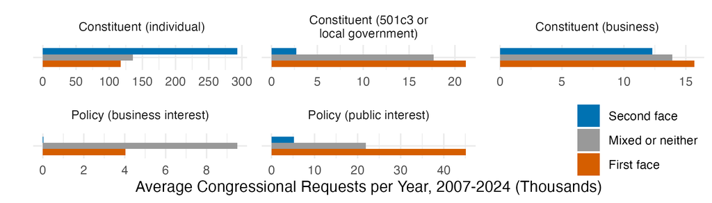

Figure 1: Congressional Office Attention to Two Faces of the Administrative State

Some famous intermediary institutions are **missing** from administrative democracy. **Parties** craft agendas and then rely on presidents and appointees to see them through. The only party-adjacent actors at the table in bureaucratic policymaking are corporate donors. The party in government is the donor-consultant faction of the party (see Jake and Paul’s memos). **Unions**, with some exceptions, are narrowly present on issues that directly affect their workplace, often mobilized by employers. National Nurses United is one of the few I engaged more broadly (Ahlquist and Levi 2013). Some broad-based groups, like AARP, are also absent.

While Second Face institutions may have evaded transparency and participation requirements, there is demand for it in the streets and in local politics. For example, municipal cooperation with ICE is now a major flashpoint of local elections. **Do second-face agencies demand different accountability institutions?**

## Identity-conscious administrative law

Feinstein (2022) argues that identity-conscious institutional design can improve agency accountability by explicitly elevating certain groups that are disadvantaged by neutral processes. If institutions aim for “equitable and meaningful” participation — to mitigate rather than reproduce structural power — must they explicitly empower race- and class-subjugated communities? We have much more research on identity-targeted benefits and enforcement than identity-conscious participation. Even without elevating certain groups, addressing the identity of participants — about who is lobbying, who they represent, who funded it — could yield more informed decisions (Seifter 2016), incent better internal governance, and strengthen civil society infrastructure (Berger et al. 2026). Despite much discussion about how participation builds legitimacy (Feinstein and Walters 2025), courts pay no attention to the democratic qualities of the policy process or who was excluded when upholding or striking down policy. Proposals to reform public participation are generally framed as neutrally increasing access, assuming that a more open process will lead to more diverse perspectives and higher quality information. What do we know about the limits of identity-neutral participatory institutions, the possibilities of identity-conscious ones, and possible tradeoffs?

Shaping identities and public discourse — disrupting one conventional wisdom and cementing another — is key to how social movements affect policy (Woodly 2015). Policy is shaped by and shapes common sense about what fairness and equal treatment entail. Unlike the first Trump administration, where bureaucrats and policy documents continued to talk about environmental justice and civil rights, efforts to shift the language of policymaking drove nearly all discussion of race, ethnicity, socioeconomic status, minority populations, underserved communities, cultural competency, disparate impact, civil rights, equity, inequality, disability, and tribal consultation to nearly zero in 2025 (e.g., Figure 2).[^2] How will these changes in policy discourse affect policy substance?

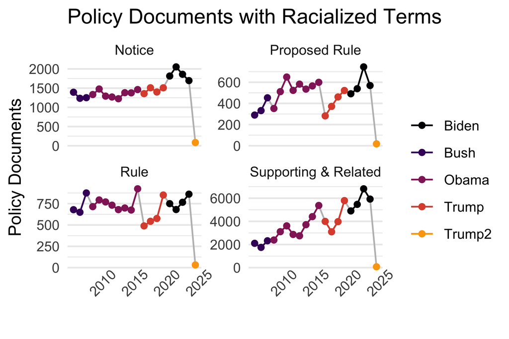

(a) Race in Policy Documents

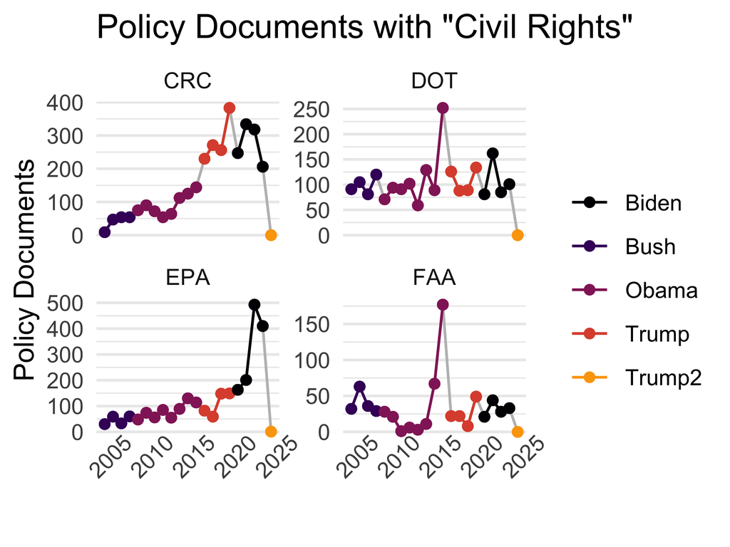

(b) “Civil Rights” in Policy Documents

Figure 2: Big Changes in Policy Discourse in 2025

## What distinguishes the first and second faces of public administration?

When critics of the administrative state exempt second-face agencies, are they exempting certain institutions, forms of state action, or policy goals? Some distinguish historically constructed **policy domains** (“domestic affairs” like education, health, and the environment versus “national security” issues like immigration, policing, and foreign affairs). Chertoff and Bulman-Pozen (2025) focus on **means** (regulation & benefits vs. surveillance & violence). Soss and Weaver (2017) focuses on similar means (coercion, containment, repression, surveillance, regulation, predation, discipline, and violence) and **ends** (social control of race- and class-subjugated communities). I [attempted to classify all federal agencies](https://docs.google.com/spreadsheets/d/18pKz-pPVvSlLs92BfVqEvqI2wsLWL3eU6ztmCVPq6bk/edit?gid=0#gid=0) for each dimension (comments welcome!).

2025 saw 58% fewer rules (Figure 3 (a)) and 56% fewer other documents than the first year of the first Trump administration. This drop in normal policymaking has been somewhat concentrated in first-face agencies (b), not necessarily liberal agencies (c).[^3] Most significantly, the decrease is almost entirely concentrated in agencies mentioned in more than 10 [paragraphs of the Heritage Foundation’s Mandate for Leadership report](https://github.com/judgelord/2025) (d).

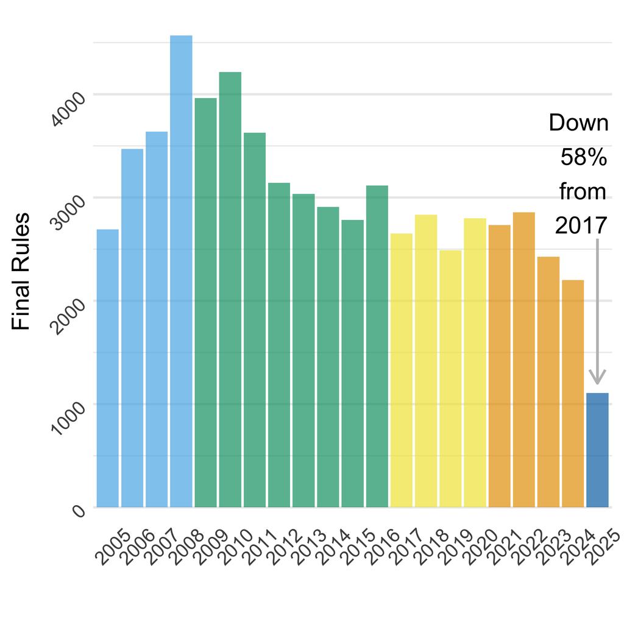

(a) Final Rules 2005-2025

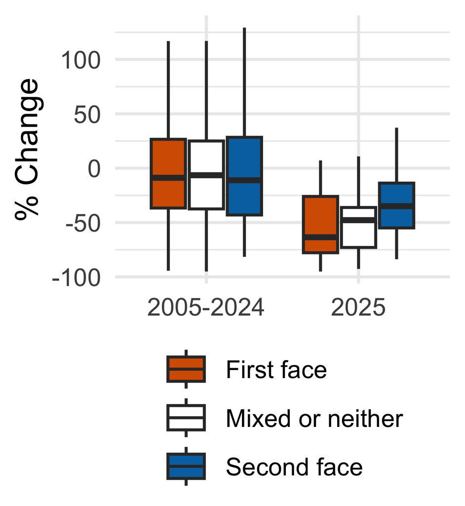

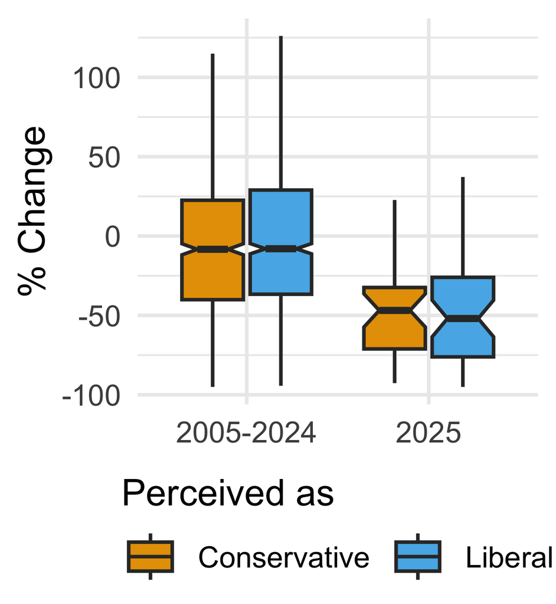

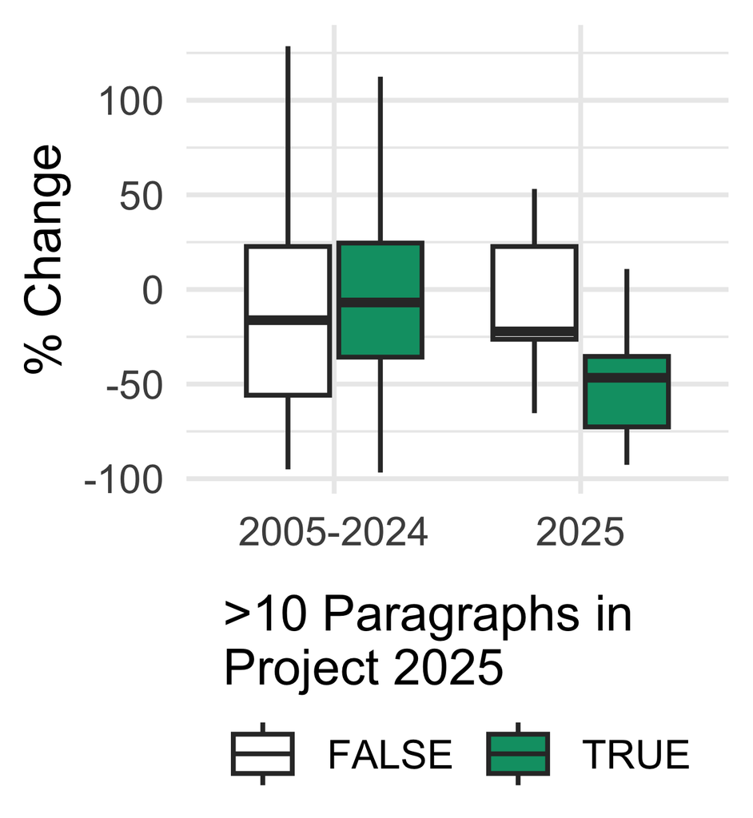

Figure 3: A Historic Decrease in Rulemaking Among Targeted Agencies in 2025

Figure 4 shows that second-face agencies are also the ones that survey respondents (Richardson et al. 2018) perceive as “conservative”; first-face agencies are more spread out, but generally perceived as “liberal,” with many agencies that don’t fit cleanly in the framework in the middle. Some have components doing different things depending on who is in power (e.g., DOJ). Some are odd fits in their larger institution (FEMA). The relationship between the face of power and the share of rules that use racialized language on the y-axis (Magaña and Judge-Lord 2025) is less clear. It is unclear where public lands agencies, public services like USPS, and science agencies fit in the scheme.

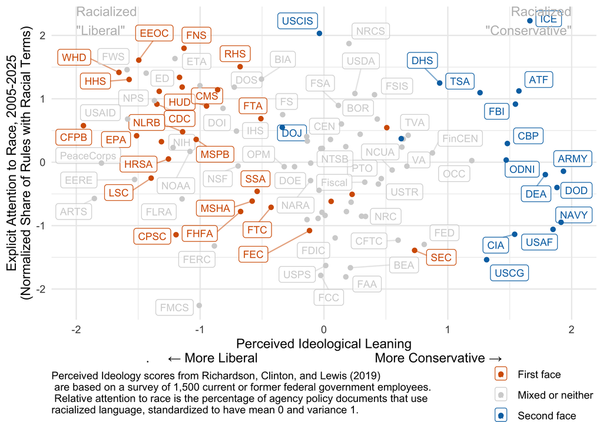

Figure 4: Two Faces of the Administrative State by Perceived Ideology and Racialization

## References

Ahlquist, John S., and Margaret Levi. 2013. *In the Interest of Others: Organizations and Social Activism*. Princeton University Press. https://books.google.com/books/about/In{\_}the{\_}Interest{\_}of{\_}Others.html?id=CimRmwEACAAJ.

Berger, Sam, Hollie Russon Gilman, Alexander Hertel-Fernandez, and K. Sabeel Rahman. 2026. *Toward Democracy-Deepening Public Participation and Engagement in Federal Policymaking*. New America. https://www.newamerica.org/insights/public-participation-in-federal-policymaking/.

Carpenter, Daniel. 2023. “Agenda Democracy.” *Annual Review of Political Science* 26: 193–212. https://doi.org/10.1146/annurev-polisci-051921-102533.

Carpenter, Daniel, Angelo Dagonel, Devin Judge-Lord, et al. 2024. *Inequality in Administrative Democracy: Large-Sample Evidence from American Financial Regulation*. American Political Science Association Annual Conference.

Chertoff, Emily R., and Jessica Bulman-Pozen. 2025. “The Administrative State’s Second Face.” *New York University Law Review* 100 (3): 809–72.

Dwidar, Maraam A. 2022. *Power to the Partners: Organizational Coalitions in Social Justice Advocacy*. University of Chicago Press.

Feinstein, Brian D. 2022. “Identity-Conscious Administrative Law: Lessons from Financial Regulators.” *George Washington Law Review* 90 (1): 1.

Feinstein, Brian D., and Daniel E. Walters. 2025. *Valuing Administrative Democracy*. Legal Studies Research Paper. Texas A&M University School of Law; The Wharton School.

Harrison, Jill Lindsey. 2019. *From the Inside Out: The Fight for Environmental Justice Within Government Agencies*. The MIT Press. https://doi.org/10.7551/mitpress/12063.001.0001.

Hertel-Fernandez, Alexander. 2025. “How Political Science Shaped Federal Policy in the Biden-Harris Administration: Learning from Efforts to Democratize the Administrative State.” *Perspectives on Politics*, 1–21.

Jones, James. 2024. *The Last Plantation*. Princeton University Press.

Judge-Lord, Devin, Eleanor Neff Powell, and Justin Grimmer. 2026. “How shifting priorities and capacity affect policy work and constituency service: Evidence from a census of legislator requests to U.S. federal agencies.” *American Journal of Political Science* n/a (n/a): 1–19. https://doi.org/https://doi.org/10.1111/ajps.70031.

Libgober, Brian, and Daniel Carpenter. 2024. “Lawyers as Lobbyists: Regulatory Advocacy in American Finance.” *Perspectives on Politics*, 1–20. https://doi.org/10.1017/S1537592723002943.

Magaña, Karla, and Devin Judge-Lord. 2025. “Racialization and Perceived Institutional Ideology.” https://judgelord.github.io/research/racialization/.

Moynihan, Donald P., and Joe Soss. 2014. “Policy Feedback and the Politics of Administration.” *Public Administration Review*, ahead of print. https://doi.org/10.1111/puar.12200.

Powell, Eleanor Neff, Devin Judge-Lord, and Justin Grimmer. 2023. “Legislator Advocacy on Behalf of Constituents and Corporate Donors: A Case Study of the Federal Energy Regulatory Commission.” In *Accountability Reconsidered: Voters, Interests, and Information in US Policymaking*, edited by Charles M. Cameron, Brandice Canes-Wrone, and Gregory A. Huber. Cambridge University Press. https://judgelord.github.io/research/ferc/.

Richardson, Mark D., Joshua D. Clinton, and David E. Lewis. 2018. “Elite Perceptions of Agency Ideology and Workforce Skill.” *The Journal of Politics* 80 (1): 303–8.

Seifter, Miriam. 2016. “Second-Order Participation in Administrative Law.” *UCLA Law Review*.

Snyder, Rochelle, Devin Judge-Lord, Eleanor Neff Powell, and Justin Grimmer. 2025. *Who Gets Constituent Service?*

Soss, Joe, and Vesla Weaver. 2017. “Police Are Our Government: Politics, Political Science, and the Policing of Race–Class Subjugated Communities.” *Annual Review of Political Science* 20: 565–91. https://doi.org/10.1146/annurev-polisci-060415-093825.

Strolovitch, Dara Z. 2006. “Do Interest Groups Represent the Disadvantaged? Advocacy at the Intersections of Race, Class, and Gender.” *The Journal of Politics* 68 (4). https://doi.org/10.1111/j.1468-2508.2006.00478.x.

Walton, Jr., Hanes. 1988. *When the Marching Stopped: The Politics of Civil Rights Regulatory Agencies*. SUNY Series in African American Studies. State University of New York Press.

Wilson, James Q. 1989. *Bureaucracy: What Government Agencies Do and Why They Do It*. Basic Books.

Woodly, Deva. 2015. *The Politics of Common Sense*. Oxford University Press. https://global.oup.com/academic/product/the-politics-of-common-sense-9780190203986.

Yackee, Jason Webb, and Susan Webb Yackee. 2006. “A Bias Towards Business? Assessing Interest Group Influence on the U.S. Bureaucracy.” *Journal of Politics* 68 (1): 128–39. https://doi.org/10.1111/j.1468-2508.2006.00375.x.